title: “Introduction to transposition” output: rmarkdown::html_vignette vignette: > % % % —

```r
library(transposition)
```

## The transposition matrix

For two distinct indices i and j, the transposition matrix is T_ij = I_n - E_ii - E_jj + E_ij + E_ji. It is the identity matrix with rows i and j swapped.

```r
matrice_T(4, 1, 3)
```

```
#>      [,1] [,2] [,3] [,4]
#> [1,]    0    0    1    0
#> [2,]    0    1    0    0
#> [3,]    1    0    0    0
#> [4,]    0    0    0    1
```

## Swapping rows and columns

T_ij A swaps rows i and j of A, and A T_ij swaps columns i and j. This works for non-square matrices too.

```r
A <- matrix(1:6, nrow = 2)
A
```

```
#>      [,1] [,2] [,3]
#> [1,]    1    3    5
#> [2,]    2    4    6
```

```r
echange(A, 1, 3, "columns")
```

```
#>      [,1] [,2] [,3]
#> [1,]    5    3    1
#> [2,]    6    4    2
```

## Properties

T_ij is its own inverse: applying the same swap twice gives back the original matrix.

```r
proprietes_T(4, 1, 3)
```

```
#> $symetrique
#> [1] TRUE
#>
#> $orthogonale
#> [1] TRUE
#>
#> $involutive
#> [1] TRUE
#>
#> $determinant
#> [1] -1
```

## Engineering example: renumbering the mesh of a heated plate

A square plate is cut into 8 x 8 = 64 nodes. The temperatures x solve K x = f, where K is the stiffness matrix and f the heat sources. A node is linked to its four neighbours, so with the natural numbering (row by row) the non-zero entries of K stay close to the diagonal.

```r
m <- 8
n <- m * m
K <- matrix(0, n, n)
for (r in 1:m) {
  for (c in 1:m) {
    k <- (r - 1) * m + c
    K[k, k] <- 4
    if (c < m) { K[k, k + 1] <- -1; K[k + 1, k] <- -1 }
    if (r < m) { K[k, k + m] <- -1; K[k + m, k] <- -1 }
  }
}
f <- seq_len(n) / n

bandwidth <- function(M) {
  idx <- which(M != 0, arr.ind = TRUE)
  max(abs(idx[, 1] - idx[, 2]))
}
spy <- function(M, title) {
  graphics::image(seq_len(ncol(M)), seq_len(nrow(M)),
                  t(M != 0)[, nrow(M):1] * 1,
                  col = c("white", "steelblue"), axes = FALSE,
                  xlab = "", ylab = "", main = title)
  graphics::box()
}

bandwidth(K)
```

```
#> [1] 8
```

The mesh generator delivers the same plate with the nodes numbered in a random order.

```r
set.seed(1)
p <- sample(n)
K_bad <- K[p, p]
f_bad <- f[p]
bandwidth(K_bad)
```

```
#> [1] 62
```

The physics is unchanged: the temperatures are the same, only listed in another order.

```r
u <- solve(K, f)
u_bad <- solve(K_bad, f_bad)
all.equal(u_bad, u[p])
```

```
#> [1] TRUE
```

The engineer now renumbers the nodes one pair at a time. Exchanging the numbers of nodes k and pos replaces K by T K T (rows and columns swapped) and f by T f. Each exchange uses the transposition matrix.

```r
K_new <- K_bad
f_new <- f_bad
current <- p
n_swaps <- 0
for (k in seq_len(n)) {
  pos <- which(current == k)
  if (pos != k) {
    Tm <- matrice_T(n, k, pos)
    K_new <- Tm %*% K_new %*% Tm
    f_new <- drop(Tm %*% f_new)
    current[c(k, pos)] <- current[c(pos, k)]
    n_swaps <- n_swaps + 1
  }
}
n_swaps
```

```
#> [1] 60
```

```r
bandwidth(K_new)
```

```
#> [1] 8
```

The natural system is recovered exactly, and so is the solution.

```r
all.equal(K_new, K)
```

```
#> [1] TRUE
```

```r
all.equal(drop(solve(K_new, f_new)), u)
```

```
#> [1] TRUE
```

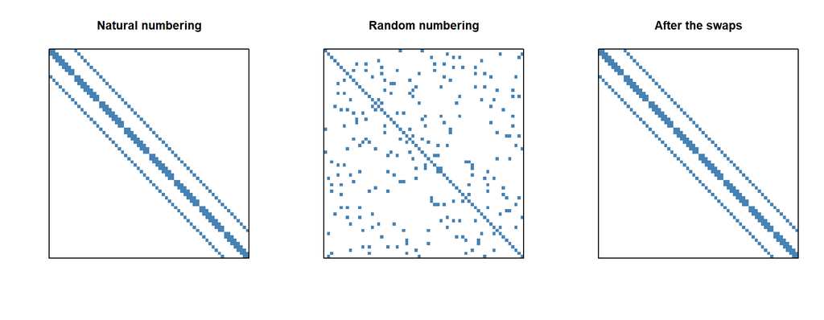

```r
old <- graphics::par(mfrow = c(1, 3))
spy(K, "Natural numbering")
spy(K_bad, "Random numbering")
spy(K_new, "After the swaps")
```

```r
graphics::par(old)
```

A banded solver costs roughly n times the square of the bandwidth, so reducing the bandwidth from about 60 to 8 divides the work by a large factor. In a real bridge or dam there are thousands of nodes, and each renumbering step is a product by a matrix T_ij.